# Data manipulation in R

## WHAT ELSE CAN WE SPECIFY FOR POINTS?

### PLOT IS SUPER GENERAL (IT WILL TRY TO PLOT ANYTHING). FACTORS DEFAULT TO BOXPLOTS…

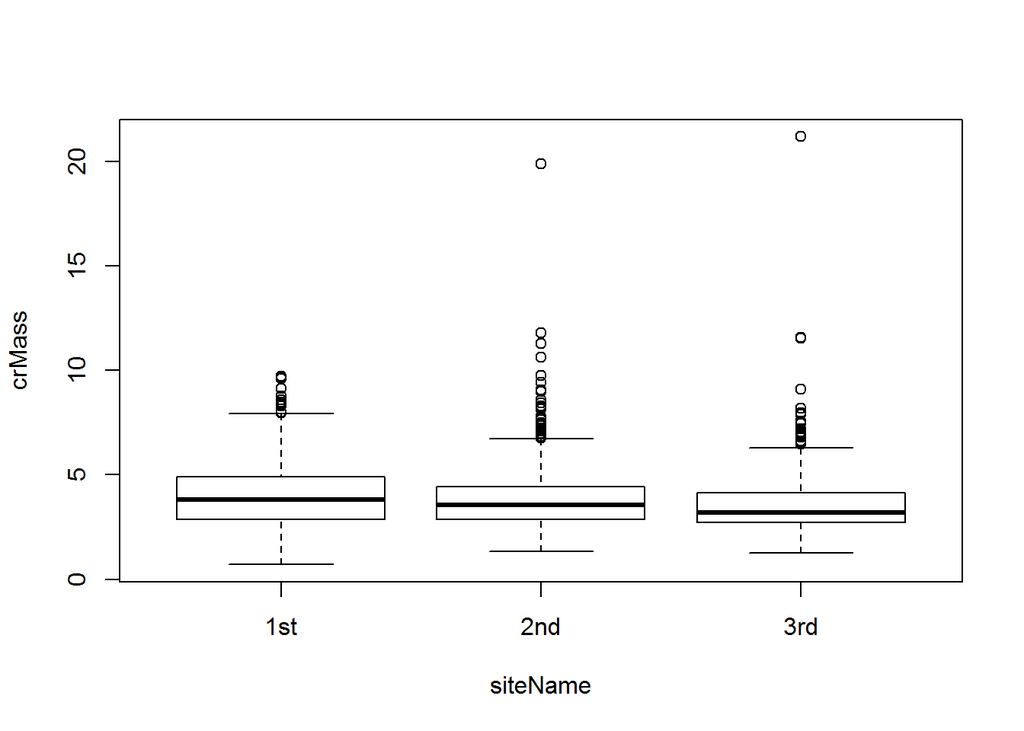

```r
plot(crMass ~ siteName, otiShells)
```

# BOX PLOTS

```r
? boxplot()
```

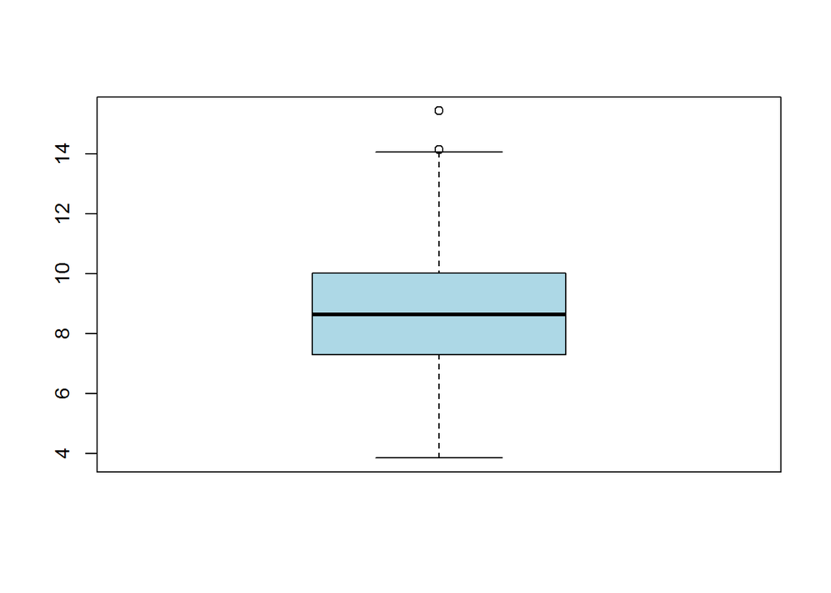

```r
boxplot(pingData$x_mm, col='lightblue')
```

## SPLIT IT BY “siteName”?

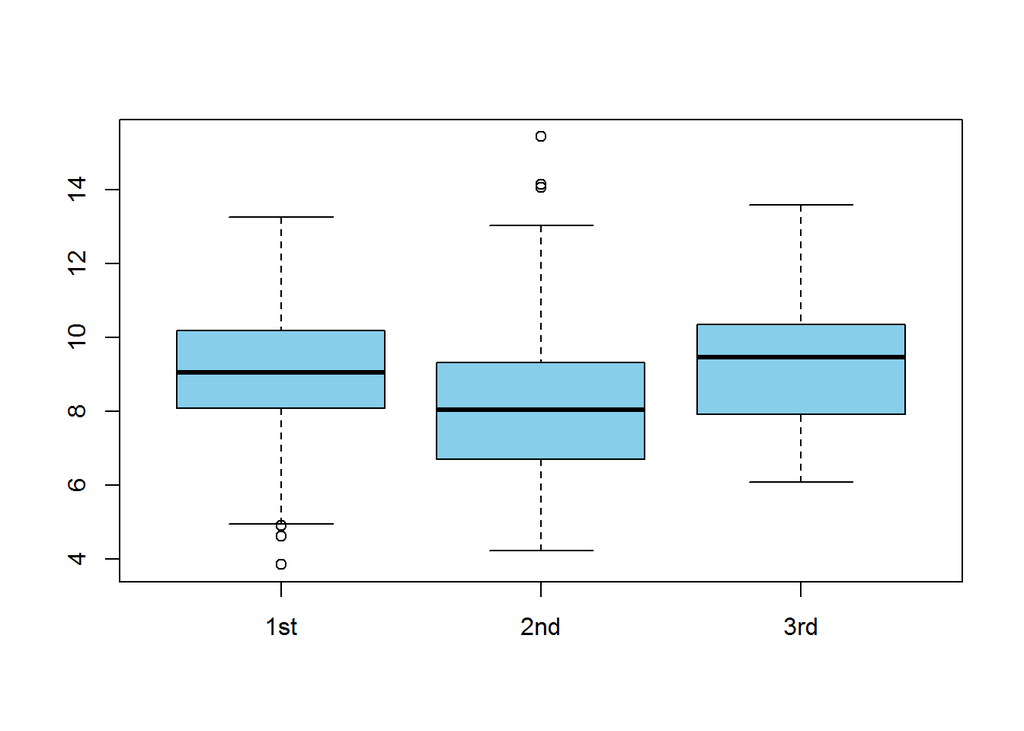

```r
boxplot(x_mm ~ siteName, pingData, col='skyblue')
```

## BETTER AXIS LABELS

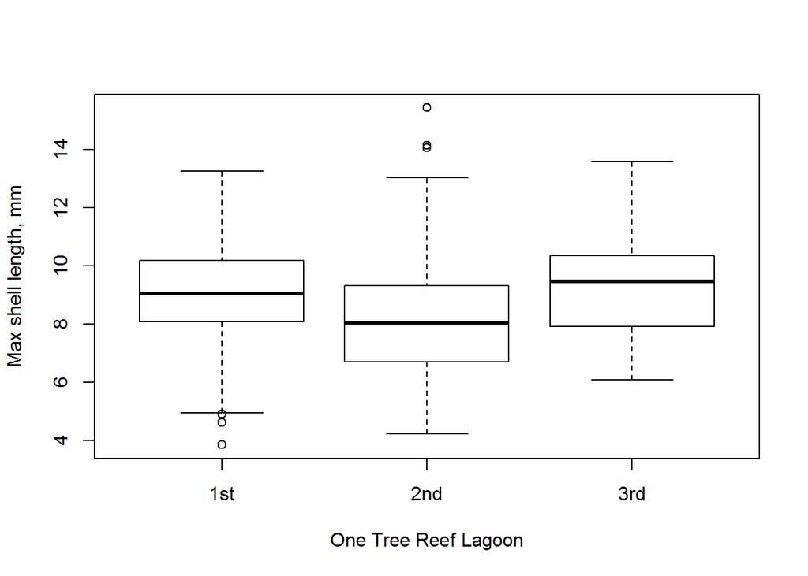

```r
boxplot(x_mm ~ siteName, pingData, xlab="One Tree Reef Lagoon", ylab="Max shell length, mm")
```

## ADD `notch`ES?

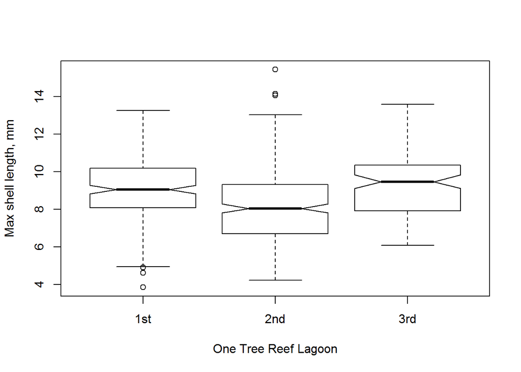

```r
boxplot(x_mm ~ siteName, pingData, xlab="One Tree Reef Lagoon", ylab="Max shell length, mm", notch = TRUE)
```

## ?? WHAT ARE THE “notch”es??

### OVERLAY THE POINTS? ( IT WORKS - IF WE MAKE Root.herbivore A FACTOR )

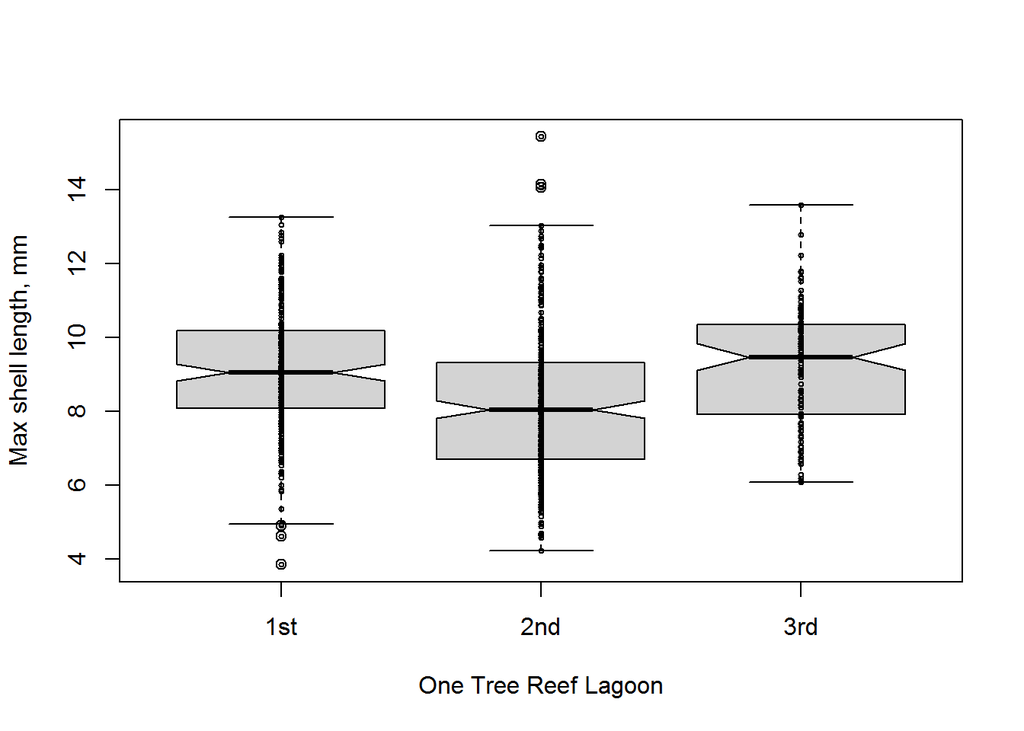

```r
boxplot(x_mm ~ siteName, pingData, xlab="One Tree Reef Lagoon", ylab="Max shell length, mm", notch = TRUE, col='lightgrey')
points(pingData$siteName, pingData$x_mm, cex=0.5)
```

# EXPLORATORY PLOTTING

```r
? pairs()
```

A VERY COOL FUNCTION, BUT ONLY WORKS WITH NUMERIC DATA Great way to quickly access collinearity among variables

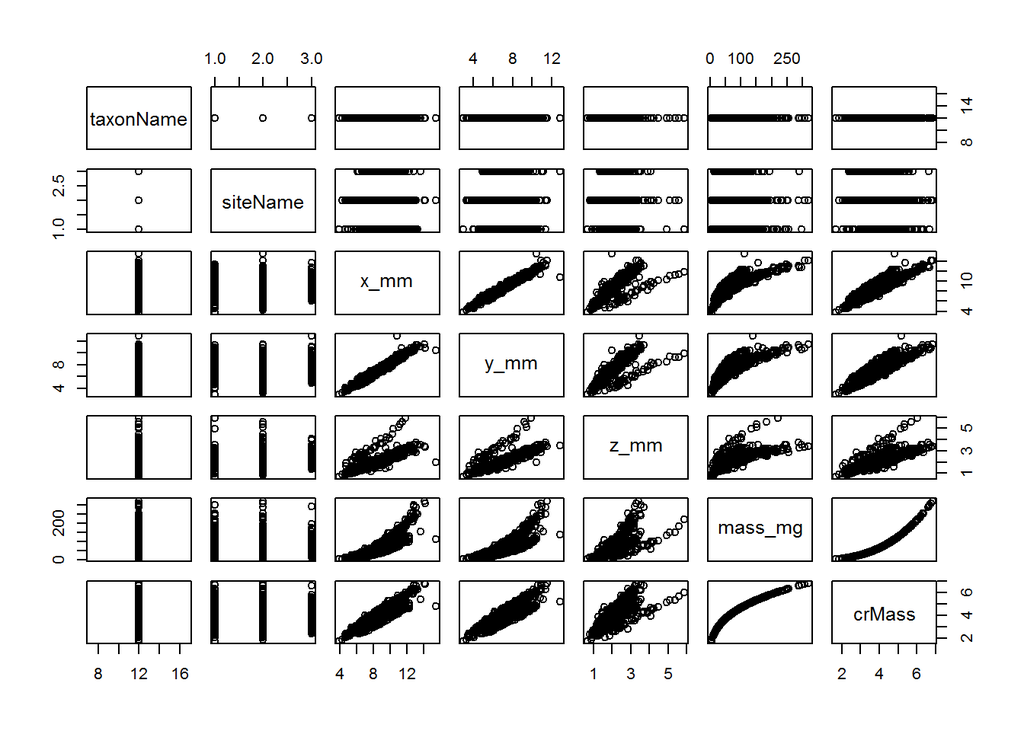

```r
pairs(pingData)
```

## WHICH COLUMNS HAVE NUMERIC DATA??

```r
names(pingData)
```

```
## [1] "taxonName" "siteName"  "x_mm"      "y_mm"      "z_mm"      "mass_mg"
## [7] "crMass"
```

```r
comps <- names(pingData)[3:7]
comps
```

```
## [1] "x_mm"    "y_mm"    "z_mm"    "mass_mg" "crMass"
```

## PLOT ALL PAIR-WISE COMPARISONS FOR NUMERIC Pinguitellina DATA

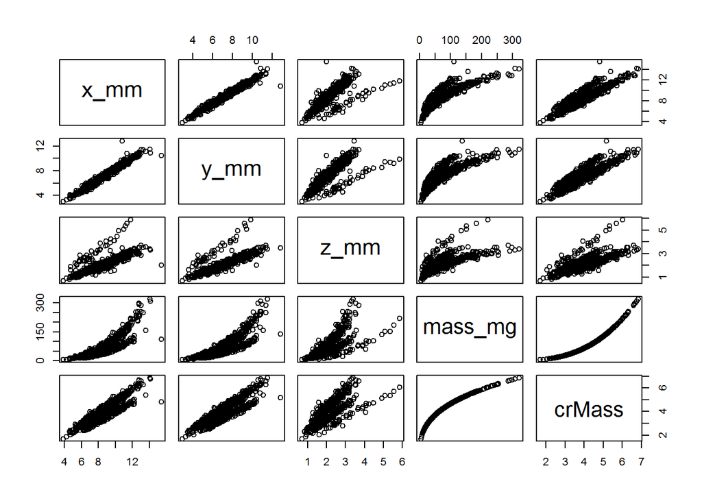

```r
pairs(pingData[comps])
```

and an explanation for why there are two relations instead of 1!

# 3D PLOTTING

LETS USE THE BUILT IN volcano DATASET FOR THIS…

```r
?volcano
```

TO GOOD BUILT IN FUNCTIONS ARE `image()` AND `contour()`

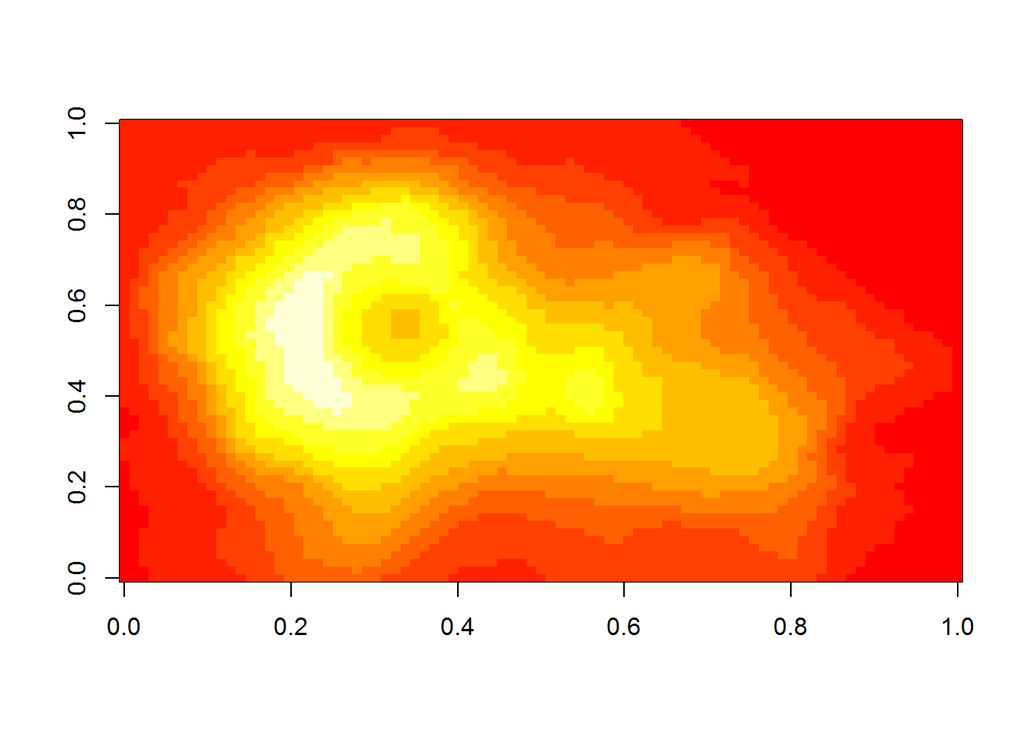

```r
image(volcano)
```

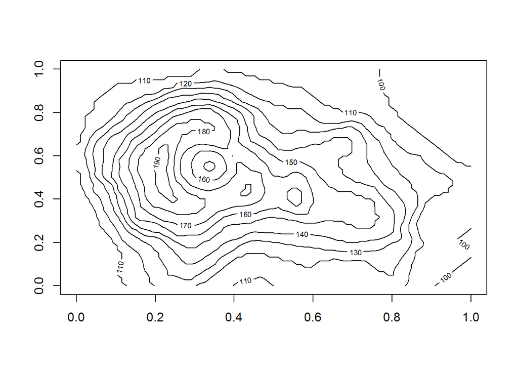

```r
contour(volcano)
```

## SPECIFY THE COLOUR GRADIENT

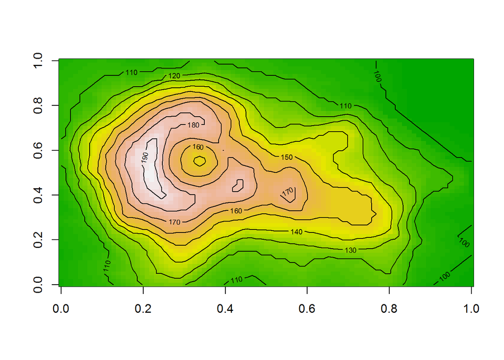

```r
image(volcano, col=terrain.colors(50))

contour(volcano, add=TRUE)
```

It is possible to read shape files, and do basic GIS type things in R.

# BAR PLOTS

I PERSONALLY REALLY DISLIKE BARPLOTS, BUT THEY ARE COMMONLY USED R DOES NOT HAVE A STANDARD ERROR FUNCTION, BUT WE CAN WRITE ONE…

```r
standard.error <- function(x) { sd(x)/sqrt(length(x)) }
```

REMEMBER ALL THE WAY BACK TO THE MORNING…

**USE** “aggregate” TO GET THE mean otiShells[‘x_mm’] BY otiShells[“taxonName”] **TIP**: USING otiShells[“x_mm”] INSTEAD OF otiShells$x_mm GIVES YOU NICER COLUMN NAMES

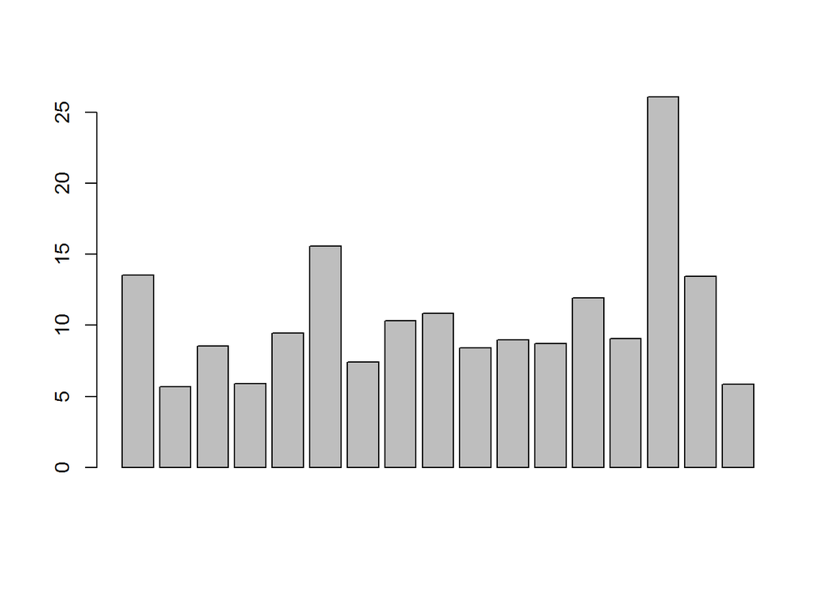

```r
mn <- aggregate(otiShells['x_mm'], otiShells["taxonName"], mean)
bp <- barplot(mn$x_mm)
```

**NOTE**: BY ASSIGNING barplot() TO bp… WE CAN DO THE NEXT STEP

USE `aggregate` TO GET THE standard.error

```r
se <- aggregate(otiShells['x_mm'], otiShells["taxonName"], standard.error)
```

ADD THE STANDARD ERROR USING arrows

```r
arrows(bp, mn$x_mm + se$x_mm, bp, mn$x_mm - se$x_mm, code=3, angle=90, length=0.1, lwd=2)
```

## ?? DOESN’T QUITE LOOK RIGHT

MAKE A BAR PLOT AND SPECIFY Y-AXIS “ylim” SO THAT THE WHOLE SE FITS IN…

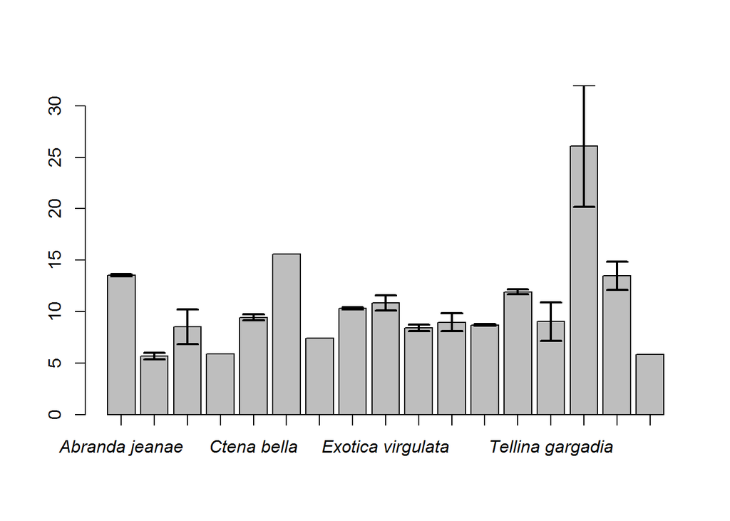

```r
bp <- barplot(mn$x_mm, ylim=c(0, max(mn$x_mm + se$x_mm, na.rm=TRUE)))
arrows(bp, mn$x_mm + se$x_mm, bp, mn$x_mm - se$x_mm, code=3, angle=90, length=0.1, lwd=2)
## ADD LABELS USING axis()
axis(1, at=bp, labels=mn$taxonName, font=3)
```

STILL NOT WHAT WE WANT BECAUSE R DOES SKIPS LABELS THAT WOULD OVER WRITE Try again but rotating the axis labels 90 degrees

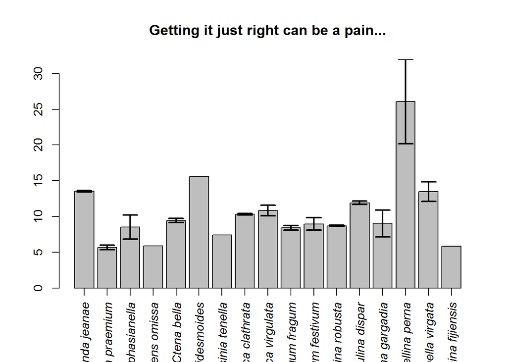

```r
bp <- barplot(mn$x_mm, ylim=c(0, max(mn$x_mm + se$x_mm, na.rm=TRUE)))
arrows(bp, mn$x_mm + se$x_mm, bp, mn$x_mm - se$x_mm, code=3, angle=90, length=0.1, lwd=2)
axis(1, at=bp, labels= mn$taxonName, las=2, font=3)
title("Getting it just right can be a pain...")
```

- HOW DO WE FIX THE MARGIN SIZE…
- SHOW ME HOW TO DO THAT CRAZY VOODOO THAT YOUDOO?
- REMEMBER IF YOU DIG DEEP ENOUGH YOU CAN TINKER WITH ANYTHING IN R
- Afraid? “You will be. You… will… be.” (Yoda)

# GLOBAL GRAPHIC PARAMETERS

```r
?par
```

- **NOTE**: NO ONE REMEMBERS ALL OF THESE PARAMETERS BUT HOPEFULLY YOU WILL REMEMBER THAT ?par GETS YOU THE ANSWER
- **NOTE**: CLOSING YOUR GRAPHING WINDOW WILL RESET YOUR GLOBAL PARAMETERS (FOR GOOD AND BAD)
- **TIP**: YOU CAN SAVE PARAMETERS TO A VARIABLE TO RESTORE YOUR OLD ONES
- **TIP**: par() WILL TELL YOU WHAT THE CURRENT PARAMETERS ARE

# SAVE CURRENT / ORIGINAL PARAMETERS

```r
oldPar <- par()
```

## SO HOW CAN WE FIX OUR MARGIN ISSUE?

# use par() to set margin. hint: try 12 for margin 1

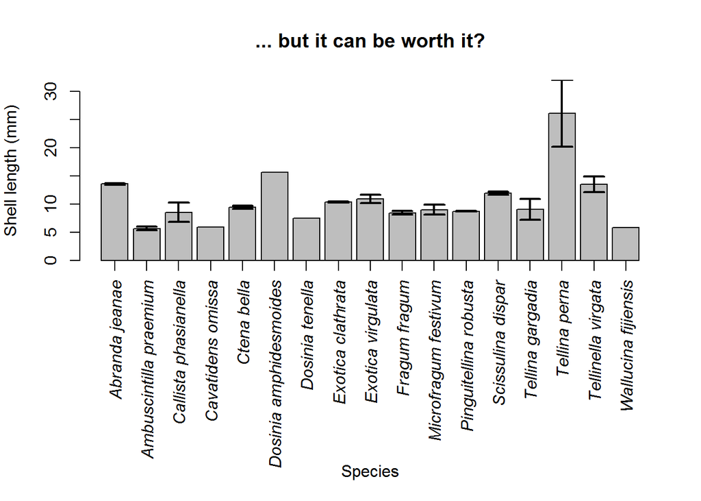

```r
par(mar=c(12, 4, 4, 2))
bp <- barplot(mn$x_mm, ylim=c(0, max(mn$x_mm + se$x_mm, na.rm=TRUE)))
arrows(bp, mn$x_mm + se$x_mm, bp, mn$x_mm - se$x_mm, code=3, angle=90, length=0.1, lwd=2)
axis(1, at=bp, labels= mn$taxonName, las=2, font=3, cex=0.7)
mtext("Species", side=1, line=10)
mtext("Shell length (mm)", side=2, line=3)
title("... but it can be worth it?")
```

## RESTORE ORIGINAL PARAMETERS

```r
par(oldPar)
```

# SAVING PLOTS

- **NOTE**: YOU CAN SAVE OR “EXPORT” THE GRAPHING WINDOW TO SAVE YOUR PLOTS
- **TIP**: DON’T SAVE OR “EXPORT” THE GRAPHING WINDOW TO SAVE YOUR PLOTS
- **TIP**: ALWAYS USE A VECTOR FORMAT (I.E., PDF) SO THAT YOUR PLOTS LOOK GOOD WHEN SCALED
- **TIP**: IF YOU MUST USE A RASTER FORMAT USE PNG RATHER THAN JPEG
- **TIP**: SAVE YOUR PLOT FROM THE COMMAND LINE! + - TOTAL CONTROL OF PLOT SIZES, ETC TO MEET SPECIFIC JOURNAL REQUIREMENTS + - YOU CAN JUST RUN A SCRIPT TO REGENERATE ALL YOUR PLOTS IF (WHEN) YOUR DATA CHANGE OR YOUR SUPERVISOR WANTS IT TO LOOK A LITTLE DIFFERENT + - EVERYTIME THE SCRIPT RUNS YOU WILL ALWAYS GET THE EXACT SAME PLOT, REPRODUCIBILITY IS KEY TO GOOD SCIENCE
- **TIP**: MAKE A SUBDIRECTORY CALLED “figs” IN YOUR PROJECT DIRECTORY

```r
dir.create("./figs")
```

**NOTE**: FANCY SCRIPT - ONLY CREATES THE DIRECTORY IF THE DIRECTORY IS NOT ALREADY THERE **TIP**: DEALING WITH THE UNEXPECTED WELL IS WHAT MAKES FLEXIBLE CODE (MOST CODE WE WRITE IT NOT FLEXIBLE)

```r
if(!("./figs") %in% list.dirs(".")) dir.create("./figs")
```

# START A PDF FILE TO WRITE TO

```r
pdf("./figs/my_barplot.pdf", width=5, height=5)
```

WHAT ARE THE UNITS OF WIDTH AND HEIGHT

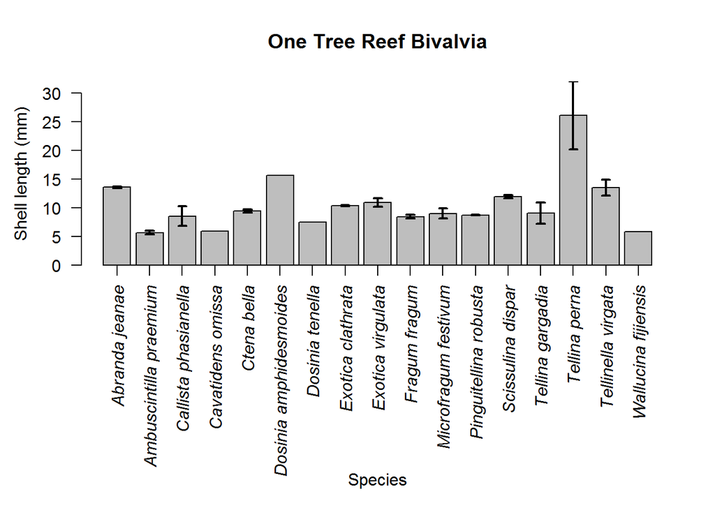

```r
par(mar=c(12, 4, 4, 2))
bp <- barplot(mn$x_mm, ylim=c(0, max(mn$x_mm + se$x_mm, na.rm=TRUE)), las=1)
arrows(bp, mn$x_mm + se$x_mm, bp, mn$x_mm - se$x_mm, code=3, angle=90, length=0.04, lwd=2)
axis(1, at=bp, labels= mn$taxonName, las=2, font=3, cex=0.7)
mtext("Species", side=1, line=10)
mtext("Shell length (mm)", side=2, line=2.5)
title("One Tree Reef Bivalvia")
```

```r
dev.off()
```

MUST ALWAYS USE `dev.off()` WHEN YOU ARE DONE WRITING TO THE FILE… OR IT STAYS OPEN…

# START A PNG FILE

```r
png(filename="./figs/my_barplot.png", width=400, height=400)
par(mar=c(12, 4, 4, 2))
bp <- barplot(mn$x_mm, ylim=c(0, max(mn$x_mm + se$x_mm, na.rm=TRUE)), las=1)
arrows(bp, mn$x_mm + se$x_mm, bp, mn$x_mm - se$x_mm, code=3, angle=90, length=0.04, lwd=2)
axis(1, at=bp, labels= mn$taxonName, las=2, font=3, cex=0.7)
mtext("Species", side=1, line=10)
mtext("Shell length (mm)", side=2, line=2.5)
title("One Tree Reef Bivalvia")
dev.off()
```

**TIP**: WHEN THINGS GO WRONG SAVING PLOTS + - IT IS NEARLY ALWAYS BECAUSE THE FILE WAS NOT CLOSED + - REPEAT dev.off() until it says “cannot shut down device”

# MULTIPLE PANEL PLOTS

### `mfrow` FILLS YOUR PANELS ACROSS THE TOP ROW AND THEN SEQUENTIAL ROWS DOWN

### `mfcol` FILLS YOUR PANELS DOWN THE LEFT MOST COLUMN FIRST…

```r
oldPar <- par()
```

## MAKE 4 HISTOGRAMS

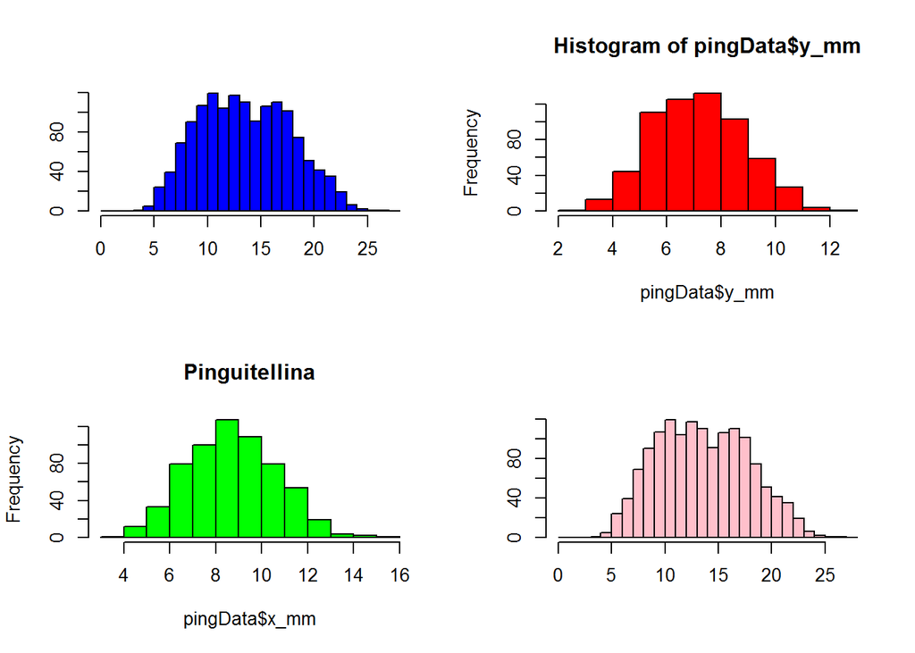

```r
par(mfcol=c(2,2))
plot(aHist, col='blue', ann=FALSE, main='Abranda')
pHist <- hist(pingData$x_mm, col='green', main='Pinguitellina')
hist(pingData$y_mm, col='red')
plot(aHist,col='pink', ann=FALSE)
```

```r
par(oldPar)
```

## LETS MAKE IT NICER…

- - SET MARGINS ALL TO 1
- - SET THE OUTER MARGINS TO c(4,3,4,2)

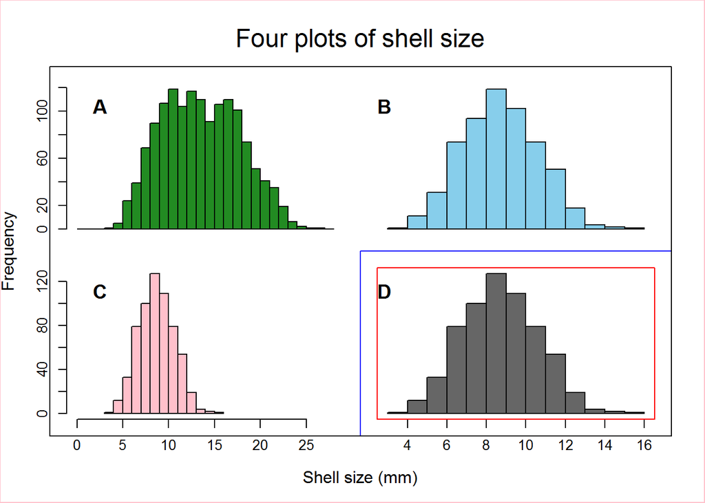

```r
par(mfrow=c(2, 2), mar=c(1, 1, 1, 1), oma=c(4, 3, 4, 2))
##  LETS ONLY PUT THE OUTER AXES ON (COMMON IF THE AXES ARE THE SAME)
##  LETS LABEL EACH PANEL A-D IN THE UPPER LEFT CORNER
plot(aHist, ann=FALSE, axes=FALSE, col='forestgreen', xlim=range(pHist$breaks, aHist$breaks))
axis(2)
mtext("A", 3, -2, adj = 0.1, font=2, cex=1.2)
hist(pingData$x_mm, ann=FALSE, axes=FALSE, col='skyblue')
mtext("B", 3, -2, adj = 0, font=2, cex=1.2)
plot(pHist, ann=FALSE, col='pink', xlim=range(pHist$breaks, aHist$breaks))
mtext("C", 3, -2, adj = 0.1, font=2, cex=1.2)
hist(pingData$x_mm, ann=FALSE, axes=FALSE, col='grey40')
axis(1)
mtext("D", 3, -2, adj = 0, font=2, cex=1.2)
box("plot", col="red")
box("figure", col="blue")
box("inner", col="black")
box("outer", col="pink")
##  mtext REALLY SHINES - PUTTING JOINT AXIS LABELS "outer"

mtext("Shell size (mm)", side=1, outer=TRUE, line=2)
mtext("Frequency", side=2, outer=TRUE, line=2)
mtext("Four plots of shell size", side=3, outer=TRUE, line=1, cex=1.5)
```

## JUST TO DEMONSTRATE THE POSSIBLE BOXES…

```r
? box()
```

```r
par(oldPar)
```

# ADDING ADDITIONAL THINGS TO PLOTS

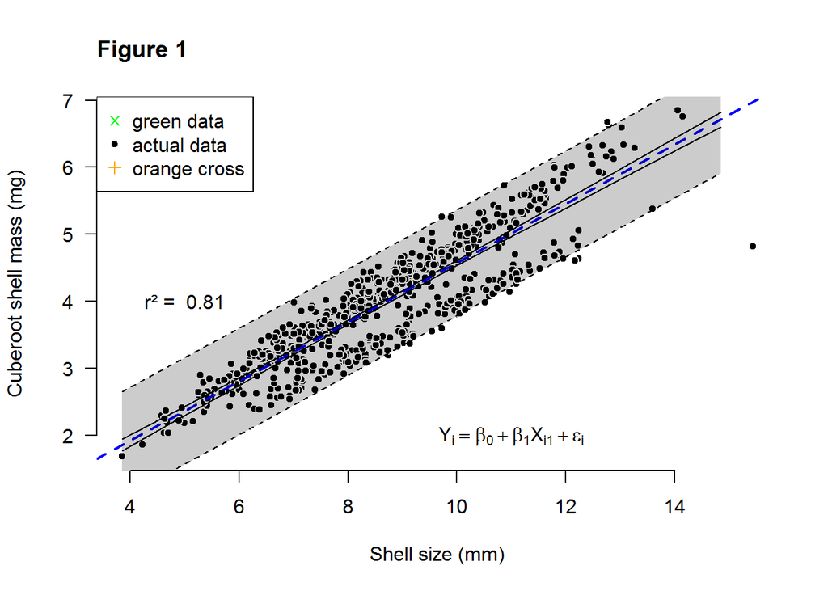

```r
plot(crMass ~ x_mm, pingData, type="p", axes=FALSE, ann=FALSE, pch=21, col="white", bg="black")
axis(1)
axis(2, las=2)
mtext("Shell size (mm)", side = 1, line = 3)
mtext("Cuberoot shell mass (mg)", side = 2, line = 3)
title("Figure 1", adj=0)
##  GET/PLOT A BEST FIT LINE USING lm()
mod <- lm(crMass ~ x_mm, pingData)
##  PLOT THE LINE USING (abline)
abline(mod, lwd=2, lty=2, col='blue')
hs <- seq(min(pingData$x_mm), max(pingData$x_mm), 1)
intPred <- predict(mod, list(x_mm = hs), interval = "prediction")
lines(hs, intPred[,"lwr"], lty = 2)

## GET/PLOT THE CONFIDENCE INTERVALS

intConf <- predict(mod, list(x_mm = hs), interval = "confidence")
lines(hs, intConf[,"lwr"])
lines(hs, intConf[,"upr"])

## PLOT A SHADED THE PREDICTION INTERVAL REGION
polygon(c(hs, rev(hs)), c(intPred[,"lwr"], rev(intPred[,"upr"])), col = rgb(0,0,0,0.2), border = NA)

##  LETS ADD THE R-SQUARED TO THE PLOT
##  TIP: UNICODE CHARACTERS ARE AN EASY WAY TO GET SOME CHARACTERS
text(5,4,paste("r\U00b2 = ",round(summary(mod)$r.squared,2)))

# ADD A LEGEND
legend("topleft", c("green data", "actual data", "orange cross"), pch=c(4, 20, 3), col=c("green", "black", "orange"), bty="y")

# ADD SOME MATH
text(11, 2, expression(Y[i] == beta[0]+beta[1]*X[i1]+epsilon[i])) # see demo(plotmath) for more examples
lines(hs, intPred[,"upr"], lty = 2)
```

NOW… WRAP THE SUPER NICE PLOTS INTO A PDF…